# Intratumor heterogeneity in epigenetic patterns - ScienceDirect

## [Seminars in Cancer Biology](https://www.sciencedirect.com/journal/seminars-in-cancer-biology)

[Volume 51](https://www.sciencedirect.com/journal/seminars-in-cancer-biology/vol/51/suppl/C), August 2018, Pages 12-21

# Intratumor heterogeneity in epigenetic patterns

https://doi.org/10.1016/j.semcancer.2018.01.010[Get rights and content](https://s100.copyright.com/AppDispatchServlet?publisherName=ELS&contentID=S1044579X17302262&orderBeanReset=true)

Under a Creative Commons [license](http://creativecommons.org/licenses/by-nc-nd/4.0/)

Open access

## Abstract

Analogous to life on earth, tumor cells evolve through space and time and adapt to different micro-environmental conditions. As a result, tumors are composed of millions of genetically diversified cells at the time of diagnosis. Profiling these variants contributes to understanding tumors’ clonal origins and might help to better understand response to therapy. However, even genetically homogenous cell populations show remarkable diversity in their response to different environmental stimuli, suggesting that [genetic heterogeneity](https://www.sciencedirect.com/topics/biochemistry-genetics-and-molecular-biology/genetic-heterogeneity) does not explain the full spectrum of tumor plasticity. Understanding epigenetic diversity across [cancer cells](https://www.sciencedirect.com/topics/medicine-and-dentistry/cancer-cell) provides important additional information about the functional state of subclones and therefore allows better understanding of tumor evolution and resistance to current therapies.

- [Previous article in issue](https://www.sciencedirect.com/science/article/pii/S1044579X17300482)
- [Next article in issue](https://www.sciencedirect.com/science/article/pii/S1044579X17300494)

## Keywords

Epigenetic intratumor heterogeneity

DNA methylation

Histone posttranscriptional modifications

Chromatin

(Sub-)clonal evolution

Single-cell analysis

Epigenetic therapy

Cancer stem cells

## 1. Introduction

Cancer is not one but a collection of many diseases. While all cancers are characterized by abnormal cell growth with the potential to invade surrounding or distant tissues, they may exhibit varying degrees of heterogeneity in phenotypic attributes related to the hallmarks of cancer, including immune response, [genetic](https://www.sciencedirect.com/topics/biochemistry-genetics-and-molecular-biology/genetics) alterations, drug response, and many more [1]. An ongoing pursuit is to categorize tumors into groups of similar characteristics and today, cancer subtyping is largely based on the organs, tissues or by the types of cells from which they arise. However, even two cancers of the same organ may vary dramatically in important tumor-associated attributes, and this intertumor heterogeneity is complemented by profound variation between [cancer cells](https://www.sciencedirect.com/topics/medicine-and-dentistry/cancer-cell) within a tumor of the same patient (intratumor heterogeneity). Although genetic intratumor heterogeneity is nowadays considered a general feature of human cancers, it does not explain the complete phenotypic diversity of tumors. For example, even genetically homogenous cell populations show remarkable diversity in their response to therapy and other environmental stimuli [2,3], suggesting that epigenetic intratumor heterogeneity also plays a prominent role.

The field of [epigenetics](https://www.sciencedirect.com/topics/biochemistry-genetics-and-molecular-biology/epigenomics) studies the mechanisms that cause heritable changes to gene expression without affecting the underlying [DNA sequence](https://www.sciencedirect.com/topics/biochemistry-genetics-and-molecular-biology/dna-sequence) [4]. Epigenetic gene regulation is essential during normal development but also frequently adapted by cancers to modulate their malignant transcriptome [5]. On the molecular level, DNA methylation, post-translational modification of [histones](https://www.sciencedirect.com/topics/biochemistry-genetics-and-molecular-biology/histone), non-coding RNAs, histone variants, and [chromatin remodeling](https://www.sciencedirect.com/topics/biochemistry-genetics-and-molecular-biology/chromatin-remodeling) are frequently differentially utilized in tumors versus their normal counterparts [6]. While all of these mechanisms may contribute to intratumor epigenetic heterogeneity, we will focus on [DNA methylation](https://www.sciencedirect.com/topics/biochemistry-genetics-and-molecular-biology/dna-methylation) and histone tail modifications as they have been most extensively studied.

Both [DNA methylation](https://www.sciencedirect.com/topics/medicine-and-dentistry/dna-methylation) and [histone modifications](https://www.sciencedirect.com/topics/medicine-and-dentistry/histone-modification) are enzymatically reversible and potentially less faithfully maintained through mitosis than genetic information. As a consequence, they might relatively contribute more strongly to cell-to-cell phenotypic variability and [tumor heterogeneity](https://www.sciencedirect.com/topics/medicine-and-dentistry/tumour-heterogeneity). Epigenetic patterns are tightly associated to a cell’s transcriptional activity [5] and may predict its potential to react to future stimuli. Therefore, profiling of epigenetic variation across cancer cells can provide important additional information about the current and prospective functional state of tumor subclones. On these grounds, the study of epigenetic intratumor heterogeneity is necessary for a holistic understanding of [clonal evolution](https://www.sciencedirect.com/topics/biochemistry-genetics-and-molecular-biology/clonal-evolution) and therapy resistance.

DNA methylation and histone marks help to establish functional domains within the genome and define boundaries between accessible regions for transcription (euchromatin) and tightly packed DNA (heterochromatin). During tumor progression, these boundaries break down, leading to restructuring of the genome architecture [7]. In complete analogy to genetic changes, epigenetic alterations may have the potential to incur a selective growth advantage to tumor cells, regardless of whether they arise stochastically [8,9] or are driven by an aberrant transcriptional program. The existence of such potential driver events was predicted by Holliday back in 1979 [10], and they were later observed in ovarian cancer [11], B-cell lymphomas [12], and other [malignancies](https://www.sciencedirect.com/topics/medicine-and-dentistry/cancer). Since the number of stem cell divisions is strongly associated with variability of cancer occurrence [13], failures to propagate an epigenetic state might also facilitate [tumor initiation](https://www.sciencedirect.com/topics/biochemistry-genetics-and-molecular-biology/tumor-initiation). An observation in favor of this argument is that the error rate of the methylation maintenance machinery (estimated at 2 × 10<sup>−5</sup> per CpG/division) is much higher than the rate of mismatches during [DNA replication](https://www.sciencedirect.com/topics/biochemistry-genetics-and-molecular-biology/dna-replication) [14]. Similarly to [somatic mutations](https://www.sciencedirect.com/topics/biochemistry-genetics-and-molecular-biology/somatic-mutation), stochastic methylation aberration in cancer is higher in regions associated with late replication time and attachment to the [nuclear lamina](https://www.sciencedirect.com/topics/biochemistry-genetics-and-molecular-biology/nuclear-lamina) [15,16]. This partially explains why genomic regions with high mutational burden tend to share locally disordered methylation and vice versa. These notions hint towards the hypothesis that the evolution on the genetic and epigenetic levels is partially concordant, as we show later in this review.

### 1.1. Models for the development of tumor heterogeneity

Two mutually not exclusive frameworks are applied to study and understand the existence and development of intratumor heterogeneity: the [cancer stem cell](https://www.sciencedirect.com/topics/biochemistry-genetics-and-molecular-biology/cancer-stem-cell) (CSC) [17] and the clonal evolution model [18] (Fig. 1). According to the CSC hypothesis, a limited number of tumor cells are able to proliferate indefinitely, and these cells are responsible for tumor initiation and growth. The idea that rare populations of dormant cells in mature tissue trigger cancer was first postulated as the ‘embryonal-rest hypothesis’ by Rudolf Virchow in 1855 [19]. CSCs generate cellular heterogeneity by establishing a differentiation hierarchy, resulting in diverse cell phenotypes within a single tumor [20]. Importantly, this hierarchy can be reversible or plastic, allowing bidirectional interconversion between CSCs and non-CSCs, since terminally differentiated cells can dedifferentiate and gain CSC properties [21,22]. Both cell intrinsic (genetic, epigenetic) and [extrinsic factors](https://www.sciencedirect.com/topics/medicine-and-dentistry/cyanocobalamin) such as the [tumor microenvironment](https://www.sciencedirect.com/topics/medicine-and-dentistry/tumor-microenvironment) could affect [cell plasticity](https://www.sciencedirect.com/topics/biochemistry-genetics-and-molecular-biology/cell-plasticity) [20], as further outlined below. CSCs exhibit epigenomic profiles similar to the ones of embryonic and [adult stem cells](https://www.sciencedirect.com/topics/biochemistry-genetics-and-molecular-biology/adult-stem-cell), characterized by harboring “bivalent” activating H3K4me3 and repressive H3K27me3 marks at (typically unmethylated) gene promoters. The targeted genes are active during embryogenesis and might contribute to keeping the balance between self-renewal capacities and commitment to lineage-specific differentiation. This balancing function might be lost by silencing of these genes during carcinogenesis, maintaining abnormal CSC properties in cancer [cell subpopulations](https://www.sciencedirect.com/topics/medicine-and-dentistry/cell-subpopulation) [23,24].

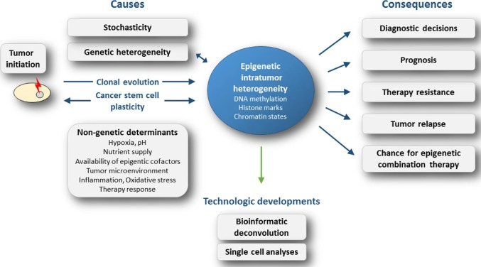

1. [Download: Download high-res image (457KB)](https://ars.els-cdn.com/content/image/1-s2.0-S1044579X17302262-gr1_lrg.jpg)
2. [Download: Download full-size image](https://ars.els-cdn.com/content/image/1-s2.0-S1044579X17302262-gr1.jpg)

Fig. 1. Tumor development follows Darwinian principles of evolution. After initial transformation of a normal cell, the malignant clone progressively evolves through microenvironmental selection pressure. Therapy may induce [tumor remission](https://www.sciencedirect.com/topics/medicine-and-dentistry/tumor-regression) but ultimately selects for resistant clones followed by an outgrowth of a treatment-resistant tumor. Epigenetic intratumor heterogeneity opens new avenues for combination treatment with epigenetic drugs and has driven major technological developments in the fields of molecular and computational biology.

In the model of clonal evolution, first proposed by Peter Nowell in 1976, tumor cells evolve through space and time and adapt to different micro-environmental conditions [[25], [26], [27]]. It is therefore analogous to the evolution of asexually reproducing species that share a common ancestor and consequently, important principles from evolutionary theory have been translated to [cancer biology](https://www.sciencedirect.com/topics/medicine-and-dentistry/cancer-pathobiology) [28,29]. Genetic intratumor heterogeneity arises through various selective forces that favor clones with increased fitness in a particular tumor microenvironment, thus leading to the co-existence of genetically distinct tumor populations [1,27]. Given the monoclonal origin of human tumors, the clonal relationship of different tumor cell populations is inferred by comparing their mutational profiles. For example, Gerlinger et al. demonstrated the presence of multiple genetically distinct tumor clones among different regions of the same [renal cell carcinoma](https://www.sciencedirect.com/topics/medicine-and-dentistry/clear-cell-renal-cell-carcinoma) and reconstructed their [phylogenetic relationship](https://www.sciencedirect.com/topics/biochemistry-genetics-and-molecular-biology/phylogeny) by calculating the genetic distances [30,31]. In theory, tumor populations that diverged more recently tend to be genetically more similar to each other than evolutionary more distant clones. Accordingly, mutations shared between multiple [clonal populations](https://www.sciencedirect.com/topics/biochemistry-genetics-and-molecular-biology/clonal-population) generally arose earlier during tumorigenesis than private mutations, *i.e.* mutations only found in a single tumor clone. Multi-clone analysis is therefore suitable to reconstruct the life history of individual tumors and to pinpoint mutational events required for tumor initiation or metastatic seeding [32]. Studies of genomic alterations have seen evidence for both neutral and convergent (parallel) evolution, cooperative and antagonistic relationships between tumor clones, as well as complex interactions with the host immune system (reviewed in [33]).

### 1.2. Intratumoral heterogeneity in prostate cancer

Prostate cancer is an intriguing example for investigating tumor heterogeneity on the genetic, epigenetic and transcriptional level. It is the second most commonly occurring tumor type among the male population [34]. Upon diagnosis, it is usually organ-confined but often manifests in more than one focus [35]. Boutros et al. found profound genetic differences between samples from different foci of the same patient – no shared copy number aberrations, and very few common [somatic mutations](https://www.sciencedirect.com/topics/medicine-and-dentistry/somatic-mutation) – highlighting the severe disadvantages of a diagnosis based on a single biopsy, and the need to better understand the contribution of individual clones to tumorigenesis [36]. Importantly, nonsynonymous [point mutations](https://www.sciencedirect.com/topics/biochemistry-genetics-and-molecular-biology/point-mutation) are rare in [prostate cancer](https://www.sciencedirect.com/topics/medicine-and-dentistry/prostate-cancer), unlike structural aberrations and changes in methylation. Methylation aberrations appear to be non-random and tightly linked to tumor progression. Intratumor methylation variability is more pronounced at enhancer elements, compared to other genomic annotations, such as gene promoters or [CpG islands](https://www.sciencedirect.com/topics/biochemistry-genetics-and-molecular-biology/cpg-island) [37]. One of the very few recurrent genetic events is the androgen receptor-associated fusion between the genes *[TMPRSS2](https://www.sciencedirect.com/topics/biochemistry-genetics-and-molecular-biology/tmprss2)* and *ERG*, leading to strong overexpression of the oncogenic [ERG protein](https://www.sciencedirect.com/topics/biochemistry-genetics-and-molecular-biology/transcription-factor-erg) [38]. This is likely an early event in tumorigenesis, as ERG-positive [prostate tumors](https://www.sciencedirect.com/topics/medicine-and-dentistry/prostate-tumor) occur predominantly in young patients [39], are characterized by a distinct methylation profile [40,41], and are even observed in histologically healthy prostate punches [42]. Using a heterogeneity [tissue microarray](https://www.sciencedirect.com/topics/biochemistry-genetics-and-molecular-biology/tissue-microarray) representing multiple regions of 190 large prostate cancers for immunohistochemical detection of ERG activation, Minner et al. reported heterogeneous ERG positivity in 42% of the informative cases [43], suggesting that a diverse mixture of epigenetically disparate clones is often contained even in a single [needle biopsy](https://www.sciencedirect.com/topics/medicine-and-dentistry/needle-biopsy).

### 1.3. Relationship between genetic alterations and epigenetic intratumor heterogeneity

Epigenetic states are established and maintained by a combination of DNA cytosine methylation and posttranslational [histone modifications](https://www.sciencedirect.com/topics/biochemistry-genetics-and-molecular-biology/histone-modification) (histone marks) mainly at lysine residues in N-terminal histone tails. They are regulated by a complex interplay of [enzymes](https://www.sciencedirect.com/topics/biochemistry-genetics-and-molecular-biology/enzyme) knowns as epigenetic regulators consisting of initiators, such as [long noncoding RNAs](https://www.sciencedirect.com/topics/biochemistry-genetics-and-molecular-biology/long-noncoding-rna) recruiting chromatin regulators to specific genomic regions, writers establishing the marks, readers interacting with specific marks, erasers removing the marks, as well as chromatin remodelers, which reposition entire nucleosomes, and chromatin insulators, which form boundaries between active and inactive chromatin domains [[44], [45], [46], [47]]. Recent large scale cancer sequencing projects have discovered widespread occurrence of mutations in the epigenetic [regulator genes](https://www.sciencedirect.com/topics/biochemistry-genetics-and-molecular-biology/locus-control-region) (reviewed in [44,48,49]). These genetic aberrations are regarded as a driving force of conferring a cell-autonomous fitness advantage to promote clonal expansion. Interest in [genetic alterations](https://www.sciencedirect.com/topics/biochemistry-genetics-and-molecular-biology/gene-mutation) of chromatin regulators as an underlying cause of epigenetic intratumor heterogeneity was spurred by the discovery of multiple distinct mutations in the H3K36me3 methyltransferase *[SETD2](https://www.sciencedirect.com/topics/biochemistry-genetics-and-molecular-biology/setd2)* (*KMT3A*) in addition to inactivating mutations in the H3K4 demethylase *KDM5C* in multiple regions of a clear cell renal cell carcinoma (ccRCC) [30]. These findings supported the concept of convergent phenotypic evolution. Loss of function of *SETD2* was confirmed by lack of immunohistochemical staining of H3K36me3 in regions harboring *SETD2* mutations [30]. In addition to *SETD2* and *KDM5C*, *KDM6A* (a H3K27 demethylase) and *[PBRM1](https://www.sciencedirect.com/topics/biochemistry-genetics-and-molecular-biology/pbrm1)* (a component of the SWI/SNF-B chromatin-remodeling complex) are also frequently mutated in ccRCC [50,51]. Ultradeep multiregion [exome sequencing](https://www.sciencedirect.com/topics/medicine-and-dentistry/exome-sequencing) of ten ccRCC cases confirmed intratumor heterogeneity in all cases and classified about 75% of all ccRCC driver mutations as subclonal. These results discourage the use of single biopsy analyses as a basis for personalized therapy decisions and explain the frequent development of resistance to [targeted therapies](https://www.sciencedirect.com/topics/medicine-and-dentistry/targeted-therapy) [31].

Gain-of-function mutation at lysine 27 of histone 3.3 (*[H3F3A](https://www.sciencedirect.com/topics/biochemistry-genetics-and-molecular-biology/h3f3a)*) in a subtype of brain tumors leads to inhibition of the [Polycomb repressive complex 2](https://www.sciencedirect.com/topics/biochemistry-genetics-and-molecular-biology/polycomb-repressive-complex-2) (PRC2) and in consequence to a genome-wide reduction of the repressive mark H3K27me3 and enhanced stem cell-like properties (reviewed in [52]).

The linker histone H1.0 is highly expressed in terminally differentiated cells. Morales-Torres et al. observed a marked heterogeneity of H1.0 immunostaining in breast cancer and established an inverse link between H1.0 expression and self-renewal capacity. Reduced H1.0 expression by intragenic enhancer hypermethylation was indicative of more aggressive tumors in glioma and breast, kidney, and stomach cancer [53]. A key finding was that loss of H1.0 facilitated destabilization of DNA-nucleosome interactions and promoted transcription of self-renewal genes, suggesting that restoring or maintaining H1.0 expression in all cancer cells might provide a therapeutic benefit.

One example of a genetic event affecting the methylome provides the IDH gene. Somatic mutations in *IDH* could be early drivers in the development of low-grade gliomas, and induce a distinct methylation pattern known as glioma CpG island methylator phenotype (CIMP) [54]. The CIMP pattern involves genes with a history of bivalency, and consequently, the tumors display a phenotype of being locked in a self-renewal state resistant to differentiation induction [24]. [DNMT3A](https://www.sciencedirect.com/topics/medicine-and-dentistry/dna-methyltransferase-3a) mutations in [acute myeloid leukemia](https://www.sciencedirect.com/topics/medicine-and-dentistry/acute-myeloid-leukemia) (AML) and other [hematological malignancies](https://www.sciencedirect.com/topics/medicine-and-dentistry/hematologic-malignancy) induce low methylation levels genome-wide [49,55]. The opposite direction of causality is also possible. For example, promoter methylation and silencing of [DNA repair](https://www.sciencedirect.com/topics/biochemistry-genetics-and-molecular-biology/dna-repair) genes such as *[MLH1](https://www.sciencedirect.com/topics/biochemistry-genetics-and-molecular-biology/mlh1)* or *MGMT* may lead to [genome instability](https://www.sciencedirect.com/topics/biochemistry-genetics-and-molecular-biology/genome-instability) or hypermutation profiles, respectively [56].

In general, the evolutionary histories of a tumor inferred based on methylation or genetic data show strong agreement with each other. The constructed phylogenies of glioma patients based on methylation and mutation data were highly concordant [57]. Copy-number and methylation heterogeneity co-evolve in the progression of prostate cancer from premalignant lesions to primary tumors and distance [metastases](https://www.sciencedirect.com/topics/medicine-and-dentistry/metastatic-carcinoma) [37]. In [esophageal squamous cell carcinoma](https://www.sciencedirect.com/topics/medicine-and-dentistry/esophageal-squamous-cell-carcinoma), the patient-specific [phylogenetic trees](https://www.sciencedirect.com/topics/biochemistry-genetics-and-molecular-biology/phylogenetic-tree) inferred based on methylation recapitulate the topological structure of the mutation-based [trees](https://www.sciencedirect.com/topics/biochemistry-genetics-and-molecular-biology/tree) [58]. Agreement in evolutionary patterns between genetic, epigenetic and [transcriptomic](https://www.sciencedirect.com/topics/biochemistry-genetics-and-molecular-biology/transcriptomics) events usually does not imply direct causality; these events are rather seen as complementary responses to internal and external stimuli in a heterogeneous population of cells [37,57]. Intratumoral variance in colorectal cancer is lower than intertumoral diversity both on the genetic and methylation level; with the methylation variability showing consistently a stronger contribution to tumor heterogeneity [59]. In [chronic lymphocytic leukemia](https://www.sciencedirect.com/topics/medicine-and-dentistry/b-cell-chronic-lymphocytic-leukemia) (CLL), the methylation variability can partially be explained by mutations or structural aberrations of known cancer-related genes, as well as [IGHV](https://www.sciencedirect.com/topics/medicine-and-dentistry/ighv) mutation status; however, methylation disorder contributes to the process of diversification [16,60]. The results of a recent study on heterogeneity in [lung adenocarcinoma](https://www.sciencedirect.com/topics/medicine-and-dentistry/lung-adenocarcinoma) suggest that somatic mutations are likely the early tumorigenic events, but DNA methylation contributes significantly to a branched evolution in later stages [61].

Accumulating evidence suggests that genetic and epigenetic events might also be indicators for independent but equally successful paths taken by tumor clones towards progression. In melanoma, for example, the deletion of the *CDKN2A/B* locus and the hypermethylation of a gene panel are observed to be mutually exclusive events, both associated with shorter time to [brain metastasis](https://www.sciencedirect.com/topics/medicine-and-dentistry/brain-metastasis) [62]. Lin et al. observed high intratumor methylation variability both in genetically stable and instable hepatocellular carcinoma cases [63] and proposed a metric for methylation variability which shows prognostic value.

In summary, these studies suggest that intricate intercommunication between genomic and epigenomic processes contributes to [phenotypic heterogeneity](https://www.sciencedirect.com/topics/biochemistry-genetics-and-molecular-biology/phenotypic-heterogeneity) in individual tumors. Epigenetic signals complement genetic data by indicating specific regulatory activity in tumor subclones. The underlying molecular mechanisms have been thoroughly reviewed by Flavahan et al. [64]. Intratumor methylation heterogeneity is a common phenomenon that reflects the evolutionary history of the disease, and has a high potential for improving cancer diagnosis and prognosis.

### 1.4. Non-genetic causes of epigenetic intratumor heterogeneity

In addition to genomic alterations, environmental and cell non-autonomous factors might play an equally important role for intratumor heterogeneity [65] (Fig. 1). In a perspicacious comment published more than 30 years ago, Gloria Heppner postulated “…regional differences in oxygen supply, acidity, nutrient supply, and the presence or absence of immunocompetent infiltrates which give growth advantages to some, but not other, cells within their spheres of influence” as selective forces from the tumor environment [66].

#### 1.4.1. Lack in oxygen and nutrient supply result in histone hypermethylation

In tumors, regional oxygen and nutrient supply is often limited by the development of disorganized and dysfunctional blood vessel networks [67]. Also, as tumors grow, glutamine as one of the major carbon and nitrogen source is strongly depleted. In line with this notion, Pan et al. described a marked reduction in levels of glutamine and α-ketoglutarate (α-KG), a TCA-cycle intermediate derived from glutamine, in the core region of [solid tumors](https://www.sciencedirect.com/topics/medicine-and-dentistry/solid-malignant-neoplasm) compared to the tumor periphery [68]. Low glutamine and α-KG levels in the central core led to massive histone hypermethylation, as α-KG is an essential cofactor for Jumonji-domain containing histone demethylases (HDMs) catalyzing the demethylation of H3K4, H3K9, H3K27 and H3K36 methylation. Hypermethylation of H3K27, but not H3K9, was associated with dedifferentiation of tumor cores and therapy resistance in a mutant BRAF melanoma model [68].

Chromatin has been suggested to act as an oxygen sensor and regulator of oxygen homeostasis. This stems from the fact that Jumonji-domain containing histone demethylases are [dioxygenases](https://www.sciencedirect.com/topics/biochemistry-genetics-and-molecular-biology/dioxygenase) with enzymatic requirements for molecular oxygen beside Fe<sup>2+</sup> and α-KG [69]. Regional lack of oxygen in tumors would reduce the [enzymatic activity](https://www.sciencedirect.com/topics/biochemistry-genetics-and-molecular-biology/enzyme-activity) and result in an accumulation of hypermethylated [histones](https://www.sciencedirect.com/topics/medicine-and-dentistry/histone). On the other hand, the majority of Jumonji-domain containing histone demethylases are inducible by hypoxia, which might indicate a feedback mechanism to regulate [histone methylation](https://www.sciencedirect.com/topics/biochemistry-genetics-and-molecular-biology/histone-methylation) [69,70]. Van den Beucken et al. analyzed a cohort of breast cancer cases from [TCGA](https://www.sciencedirect.com/topics/medicine-and-dentistry/the-cancer-genome-atlas) and METABRIC for hypoxia-inducible genes and expression of DICER, a key enzyme of [microRNA](https://www.sciencedirect.com/topics/medicine-and-dentistry/microrna) processing [71]. Samples with highest hypoxia scores had lowest DICER mRNA levels and worst prognosis. Hypoxia and hypoxia mimetics led to a massive global induction of the repressive mark H3K27me3, local accumulation at the DICER promoter and lowered DICER mRNA levels in various [cancer cell lines](https://www.sciencedirect.com/topics/medicine-and-dentistry/cancer-cell-line). These hypoxia-induced effects were phenocopied by knockdown or inhibition of KDM6A/B, the H3K27me3 HDMs, and reversed by knockdown or inhibition of the H3K27 methyltransferase [EZH2](https://www.sciencedirect.com/topics/biochemistry-genetics-and-molecular-biology/ezh2) (KMT6A), indicating a functional role of dynamic H3K27 methylation in the regulation of DICER expression. As a result, hypoxia affected miRNA processing and resulted in the induction of epithelial-to-mesenchymal transition (EMT) and acquisition of stem cell properties [71] (reviewed in [72]).

Using KDM5B (a H3K4 HDM) expression as a biomarker, Roensch et al. identified in typically highly heterogeneous melanoma a small subpopulation of slow-cycling cells with stem cell characteristics that had high potential to maintain tumor growth and to escape from cancer therapies [73]. Interestingly, KDM5B positivity was not restricted to stem cell-like cells, but was inducible in cultured [melanoma cells](https://www.sciencedirect.com/topics/medicine-and-dentistry/melanoma-cell) under hypoxic conditions, suggesting dynamic and adaptive plasticity of cancer stemness in tumor subpopulations [24,52,74]. KDM5B plays a key role in cell fate decision and is frequently overexpressed in various epithelial cancers, although functional consequences are not completely understood [73]. Beside the influence on histone demethylases, Chen et al. reported that hypoxia increased H3K9me2 levels by elevating the expression of the [histone methyltransferase](https://www.sciencedirect.com/topics/biochemistry-genetics-and-molecular-biology/histone-methyltransferase) G9a (KMT1c) in cultured human lung cancer cells [75], providing an additional layer of response of chromatin regulators to changing oxygen supply.

Overall, these data indicate a certain degree of plasticity in posttranslational histone modifications in response to changes in nutrient or oxygen supply. As, for example, genomic regions with large organized H3K9-modifications regulate cell type-specific gene expression in differentiated cells, their loss might be associated with dedifferentiation and reprogramming of cancer cells to a more stem cell-like phenotype [52]. On the other hand, focal gain in the repressive mark H3K27me3 might contribute to EMT, enhance the migratory potential of cancer cells, and contribute to metastasis formation and hence poor clinical outcome.

#### 1.4.2. Intracellular acidity regulates chromatin acetylation

McBrian et al. established a link between [histone acetylation](https://www.sciencedirect.com/topics/biochemistry-genetics-and-molecular-biology/histone-acetylation) and regulation of [intracellular pH](https://www.sciencedirect.com/topics/biochemistry-genetics-and-molecular-biology/cell-ph) [76]. A decreasing pH leads to global deacetylation of histones by [histone deacetylases](https://www.sciencedirect.com/topics/biochemistry-genetics-and-molecular-biology/histone-deacetylase) (HDACs); [monocarboxylate transporters](https://www.sciencedirect.com/topics/biochemistry-genetics-and-molecular-biology/monocarboxylate-transporter) (MCTs) coexport the released acetate anions together with protons out of the cell, preventing a further drop in pH. The authors suggested that chromatin acetylation acts as a buffer for [intracellular pH](https://www.sciencedirect.com/topics/medicine-and-dentistry/cell-ph). These data were consistent with the observation that cancers with acidic microenvironment and low frequency of acetylation marks are associated with poor clinical outcome [77]. Experimentally, a reduced supply in glucose, glutamine, and [pyruvate](https://www.sciencedirect.com/topics/medicine-and-dentistry/pyruvic-acid) as carbon sources for acetyl-Co-A as a cofactor for acetylation reactions [78] also resulted in reduced [histone acetylation](https://www.sciencedirect.com/topics/medicine-and-dentistry/histone-acetylation), albeit with different kinetics than a change in pH, indicating distinct underlying mechanisms [76].

#### 1.4.3. Tumor microenvironment (TME)-induced epigenetic heterogeneity

The tumor microenvironment (TME) represents the molecular and cellular environment surrounding a tumor. The TME consists of cells of the innate immune system as well as adaptive [immune cells](https://www.sciencedirect.com/topics/biochemistry-genetics-and-molecular-biology/immunocompetent-cell). In addition, [stromal cells](https://www.sciencedirect.com/topics/biochemistry-genetics-and-molecular-biology/stromal-cell) of the TME include fibroblasts, [myofibroblasts](https://www.sciencedirect.com/topics/medicine-and-dentistry/myofibroblast), adipocytes, [neuroendocrine cells](https://www.sciencedirect.com/topics/biochemistry-genetics-and-molecular-biology/neuroendocrine-cell), and [endothelial cells](https://www.sciencedirect.com/topics/medicine-and-dentistry/endothelial-cell). The [extracellular matrix](https://www.sciencedirect.com/topics/medicine-and-dentistry/extracellular-matrix) (ECM) and ECM-modifying enzymes, as well as secreted signaling molecules (cytokines, growth factors, [chemokines](https://www.sciencedirect.com/topics/medicine-and-dentistry/chemokine), pro-angiogenic factors) also critically contribute to the TME [79,80]. Functionally, the TME can constitute a [stem cell niche](https://www.sciencedirect.com/topics/medicine-and-dentistry/stem-cell-niche) for CSCs [80].

It is well established that [chronic inflammation](https://www.sciencedirect.com/topics/medicine-and-dentistry/chronic-inflammation) (caused by chronic infections, obesity, pollutants, tobacco use etc.) represents a risk factor for developing cancer [21]. An estimated 20% of cancer deaths are related to chronic infections and inflammation. Pro-inflammatory cytokines (IFNγ, IL-1β, IL-6, TGF-β) released by [immune cells](https://www.sciencedirect.com/topics/medicine-and-dentistry/immunocompetent-cell) in the TME have been shown to alter DNA methylation, 5-hydroxymethylation, histone marks and non-coding RNA expression (reviewed in [80]). They are involved in activation or stabilization of transcription factors such as [Snail](https://www.sciencedirect.com/topics/medicine-and-dentistry/snail), Twist, [ZEB1](https://www.sciencedirect.com/topics/biochemistry-genetics-and-molecular-biology/zeb1) and [ZEB2](https://www.sciencedirect.com/topics/biochemistry-genetics-and-molecular-biology/zeb2) regulating EMT, a process which often occurs at the tumor invasive front and facilitates migration of tumor cells and metastases formation [81]. The process is plastic, since dependent on the microenvironment, mesenchymal cells can revert back to an epithelial phenotype by mesenchymal-to-epithelial transition (MET). It has been shown that EMT increases CSC-like characteristics in tumor cells and is a major contributor to intratumor heterogeneity. The process is also supported by cancer-associated fibroblasts (CAFs) [80]. CAFs secrete a cocktail of growth factors and [chemokines](https://www.sciencedirect.com/topics/biochemistry-genetics-and-molecular-biology/chemokine) that were shown by Pistore et al. to induced massive changes in DNA methylation associated with EMT and MET in prostate cancer cells [82]. In the basal subtype of breast cancer, TGF-β signaling induced a switch from poised to active chromatin marks and induced expression of ZEB1, concomitant with the conversion of non-CSCs to CSC populations [83]. Stable epigenetic suppression of the epithelial marker E-cadherin, a target of ZEB1, in mesenchymal cells was mediated by repressive H3K9 and H3K27 methylation marks and supported maintenance of a CSC state [80].

In addition to pro-inflammatory cytokines, (tumor-associated) macrophages in the TME also release [reactive oxygen species](https://www.sciencedirect.com/topics/medicine-and-dentistry/reactive-oxygen-species) [84]. O’Hagan et al. demonstrated that oxidative stress–induced oxidative damage induced formation and relocalization of a large silencing complex containing DNMTs, the histone deacetylase [SIRT1](https://www.sciencedirect.com/topics/biochemistry-genetics-and-molecular-biology/sirtuin1), and [Polycomb group proteins](https://www.sciencedirect.com/topics/biochemistry-genetics-and-molecular-biology/polycomb-group-proteins) to initiated progressive chromatin alterations and hypermethylation of GC-rich genomic regions [85]. In addition, [oxidative stress](https://www.sciencedirect.com/topics/biochemistry-genetics-and-molecular-biology/oxidative-stress) was shown to induce a complex of [DNMT1](https://www.sciencedirect.com/topics/biochemistry-genetics-and-molecular-biology/dnmt1) and TET2, a key protein involved in active demethylation. Zhang et al. demonstrated that the DNMT1-TET2 complex formation was stabilized by acetylation of TET2, and that upregulation of deacetylases [HDAC1](https://www.sciencedirect.com/topics/medicine-and-dentistry/hdac1) and [HDAC2](https://www.sciencedirect.com/topics/biochemistry-genetics-and-molecular-biology/histone-deacetylase-2) in cancer cells might counteract the protective effect of TET2 against oxidative stress-induced hypermethylation. Loss or inhibition of TET functions, for example by mutations (as frequently observed in leukemia) or increased production of the inhibitory oncometabolite 2-hydroxyglutarate generated by mutant IDH1/2 would result in aberrant DNA hypermethylation [86].

Taken together, these data underline how local variation in TME composition and TME signals can contribute to epigenetic heterogeneity in genetically identical cancer cells within one tumor.

### 1.5. Epigenetic intratumor heterogeneity has prognostic potential

*In situ* immunohistochemical staining allows detection of proteins and their post-translational modifications in cancer cells in the context of their microenvironment, with the advantage of providing information on topological heterogeneity within solid tumors [87]. In a seminal study by Seligson et al. [88], among prostate cancer patients with low-grade tumors, staining frequencies of five histone marks discriminated two subgroups with high and low [tumor recurrence](https://www.sciencedirect.com/topics/medicine-and-dentistry/tumor-recurrence) [88], supporting the notion that increased intratumor heterogeneity at the level of chromatin states was associated with poor clinical outcome. A series of similar studies followed this pioneering work, demonstrating prognostic relevance of alterations in staining frequencies of histone marks in various tumor types. Although these studies were not *a priori* designed for this research purpose, they provide information on epigenetic intratumor heterogeneity [89] and its link to clinical outcome (Table 1).

Table 1. Histone marks with heterogeneous staining frequencies and link to prognosis.

[output not shown]

**a**

Percentage of cells with positive nuclear staining for specific histone marks, alone or in combination with intensity scoring, in association with disease outcome: ↓ Low frequency of histone mark associated with poor prognosis, ↑ high frequency associated with poor prognosis. Nuclear staining frequencies of tumor cells close to 0 or 100% represent homogeneous tumors, whereas intermediate staining frequencies indicate intratumor heterogeneity [89]. The cutoff percentage for defining subgroups with distinct clinical outcome differs between histone marks and studies.

On the methylation level, the degree of intratumor heterogeneity and its connection to tumor progression also seems to be dependent on tumor type. Multifocal analysis showed very high variability for breast [90] and prostate [37] cancers. Cases of indolent CLL, on the other hand, show remarkably stable methylation profiles across large time spans [91]. More aggressive CLL phenotypes and short time-to-first treatment cases are associated with increased methylation heterogeneity [92]. Multiple studies have shown that DNA methylation heterogeneity is also a reliable predictor for survival in diffuse large B-cell lymphomas (reviewed in [93]). Localized lung adenocarcinoma patients who relapse are characterized by higher levels of methylation intratumoral heterogeneity at the time of diagnosis [61]. Similarly, the accumulation of methylation and other epigenetic alterations in ovarian cancer is associated with advancing grade and stage of the disease [94]. However, methylation heterogeneity is an indicator for a longer relapse-free and [overall survival](https://www.sciencedirect.com/topics/biochemistry-genetics-and-molecular-biology/overall-survival) in locoregional colorectal cancer [59]. This example suggests that the complex cellular molecular systems, interconnected organ substructures and driving forces behind tumor evolution might prevent us from constructing a unified model for intratumor epigenetic diversity, applicable to all [cancer types](https://www.sciencedirect.com/topics/medicine-and-dentistry/cancer-types) and stages.

### 1.6. Epigenetic intratumor heterogeneity contributing to therapy resistance and as a chance for epigenetic combination therapy

Epigenetic intratumor heterogeneity complicates personalized treatment decisions and can contribute to the development of therapy resistance and tumor relapse [95] (Fig. 1). Anti-cancer therapies that target [CSC signaling](https://www.sciencedirect.com/topics/biochemistry-genetics-and-molecular-biology/signal-transduction) pathways or CSCs-specific surface antibodies are bound to fail if CSCs are regenerated from non-CSCs upon treatment end. Even therapies that target the stem cell niche, such as EGFR-EGF inhibitors in color cancer, eventually become ineffective as the tumors develop resistance [22]. Although anti-cancer therapies introduce a strong selection pressure, they do not necessarily lead to reduced intratumoral heterogeneity [95]. A study on samples from 47 breast cancer patients before and after chemotherapy showed no change in [genetic diversity](https://www.sciencedirect.com/topics/biochemistry-genetics-and-molecular-biology/genetic-divergence), coupled with strong changes in cellular phenotype, implying a shift in the epigenetic landscape [96].

Alternatively, the widespread alterations in expression and function of epigenetic regulators during carcinogenesis open new avenues for [epigenetic therapies](https://www.sciencedirect.com/topics/biochemistry-genetics-and-molecular-biology/epigenetic-therapy) alone or in combination with targeted therapies. Intervention with γ-secretase inhibitors (GSI) have been tested in [clinical trials](https://www.sciencedirect.com/topics/biochemistry-genetics-and-molecular-biology/clinical-trial) and mouse models of [T cell acute lymphoblastic leukemia](https://www.sciencedirect.com/topics/medicine-and-dentistry/acute-lymphoblastic-leukemia) (T-ALL) with activating *NOTCH1* mutations. After transient response, cells become tolerant to treatment, indicating outgrowth of a preexisting subpopulation of T-ALL cells in the absence of NOTCH1 signaling. To investigate underlying mechanisms of resistance, Knoechel et al. generated a population of persister cells which had elevated global levels of repressive histone modifications and [heterochromatin protein 1](https://www.sciencedirect.com/topics/biochemistry-genetics-and-molecular-biology/heterochromatin-protein-1) (HP1) and reduced chromatin accessibility [97]. A [shRNA](https://www.sciencedirect.com/topics/medicine-and-dentistry/short-hairpin-rna) knockdown screen of ∼350 chromatin regulators identified *[BRD4](https://www.sciencedirect.com/topics/biochemistry-genetics-and-molecular-biology/brd4)* as a top hit required for proliferation of persister cells. BRD4 is a bromodomain protein and functions as a reader of histone acetylation. Accordingly, persister cells were ∼5-fold more sensitive to treatment with JQ1, a [small molecule](https://www.sciencedirect.com/topics/biochemistry-genetics-and-molecular-biology/small-molecule) inhibitor of Bromodomain and extra-terminal (BET) family proteins (iBET), than naïve cells, due to downregulation of oncogenic MYC and anti-apoptotic BCL2. *In vitro*, combination treatment of T-ALL cells with GSI and JQ1 was more effective than either treatment alone. The same was true for three patient-derived T-ALL [xenografts](https://www.sciencedirect.com/topics/medicine-and-dentistry/xenograft) in [NSG mice](https://www.sciencedirect.com/topics/biochemistry-genetics-and-molecular-biology/nod-scid-gamma-mouse), as intervention with a NOTCH inhibitor and JQ1 significantly prolonged survival compared to single agent treatment. These data support further investigation of combination treatments with [epigenetic therapies](https://www.sciencedirect.com/topics/medicine-and-dentistry/epigenetic-therapy) [97]. Various inhibitors of DNMTs (DNMTi) and chromatin regulators including HDACs (HDACi), EHZ2, KDM1A, BET family proteins and others are currently tested in [clinical trials](https://www.sciencedirect.com/topics/medicine-and-dentistry/clinical-trial) (overview in [98]), and might in the future help to combat therapy resistance and reduce the need for individualized precision medicine. Although [Azacytidine](https://www.sciencedirect.com/topics/biochemistry-genetics-and-molecular-biology/azacitidine) and [Decitabine](https://www.sciencedirect.com/topics/medicine-and-dentistry/decitabine) as DNMTi and [Vorinostat](https://www.sciencedirect.com/topics/medicine-and-dentistry/vorinostat) and [Romidepsin](https://www.sciencedirect.com/topics/biochemistry-genetics-and-molecular-biology/romidepsin) as HDACi are approved for epigenetic therapies for several years by now, their [biological effects](https://www.sciencedirect.com/topics/biochemistry-genetics-and-molecular-biology/biological-activity) (on- and off-target) are still not completely understood. We [99] and others (reviewed in [98]) have identified activation of [cancer testes antigens](https://www.sciencedirect.com/topics/medicine-and-dentistry/cancer-testis-antigen) and [endogenous retroviruses](https://www.sciencedirect.com/topics/medicine-and-dentistry/endogenous-retrovirus) after treatment with DNMTi and HDCAi alone and in combination. These findings offer exciting new possibilities for combination with [immune checkpoint](https://www.sciencedirect.com/topics/biochemistry-genetics-and-molecular-biology/immune-checkpoints) therapies.

### 1.7. Quantification of methylation and intratumor methylation heterogeneity

As discussed previously in this review, studies based on nuclear staining, as well as on profiling multiple foci reveal prominent intratumoral epigenetic heterogeneity. It has become evident that the methylation profile obtained for a [bulk](https://www.sciencedirect.com/topics/biochemistry-genetics-and-molecular-biology/volume) tumor sample is an average signal for a collection of tumor subclones as well as other (healthy) cells. In addition to cell type composition, the methylation profile is also highly influenced by cell cycle stage, genetic variation and patient age. Moreover, most of the commonly used techniques to measure DNA methylation rely on [sodium bisulfite](https://www.sciencedirect.com/topics/biochemistry-genetics-and-molecular-biology/sodium-bisulfite) conversion and do not discriminate between 5-hydroxymethylated (5hmC) and methylated cytosines (5mC) [100]. Therefore, the observed result is the combined signature of two different [epigenetic modifications](https://www.sciencedirect.com/topics/biochemistry-genetics-and-molecular-biology/epigenetic-modification) that serve distinct functions and are regulated by independent mechanisms [101,102]. The disadvantages listed above introduce a major challenge to the analysis of methylome data generated in multiple studies and in large international consortia such as The Cancer Genome Atlas project (TCGA) and the International Cancer Genome Consortium (ICGC).

Here, we briefly outline the computational methods developed to tackle the shortcomings of measuring DNA methylation of a bulk sample (Table 2). Their goal is to infer the methylation patterns and relative abundancies of the present subclones. Generally, the problem of identifying individual epigenetically-determined cell populations and their contributions depends on two factors: (1) whether the methylation profiles of individual cell types are known, and (2) which technology is used to measure DNA methylation.

Table 2. Computational approaches and pipelines for inferring DNA methylation-based subclones of bulk samples.

| Tool/Method | Additional data needed | Supported Methylation Assays | Method | Availability | Reference |
| --- | --- | --- | --- | --- | --- |
| Houseman | Reference methylomes | any | Regression calibration | R source code | [103] |
| BayesCCE | Cell type fractions | any | Bayesian estimation | MatLab source code | [105] |
| RefFreeCellMix | none | any | Unconstrained NMF | R package | [155] |
| MeDeCom | none | any | Regularized NMF | R package | [107] |
| Bratwurst | none | any | Unconstrained NMF | R package | [156] |
| BED | none | RRBS | Bayesian estimation | R package | [110] |

Houseman et al. developed an algorithm that uses reference DNA methylation profiles of purified cell types to infer the cell-type proportions *via* a constrained projection procedure [103]. This reference-based algorithm was tested on and is widely applied for blood samples. The methylomes of individual cell types in blood and bone marrow are well characterized for two reasons. First, blood is a readily available tissue. Second, B- and T-cell maturation phases are defined by distinct phenotypic features and the corresponding cell populations can be isolated using [cell surface marker](https://www.sciencedirect.com/topics/biochemistry-genetics-and-molecular-biology/cell-surface-marker) proteins (reviewed in [104]).

Bayesian Cell Count Estimation (BayesCCE) is a semi-supervised method that can be applied when reference methylomes are unknown but experimentally obtained cell count information on the studied dataset is available [105]. This method generates components, each of which tends to be very highly correlated with the methylome of a single cell type. Notably, this method can be applied when cell type fractions are available for only some of the individuals in the analyzed cohort. In such a scenario, BayesCCE is able to infer the cell type fractions for the remaining samples in the cohort.

When neither the reference methylomes, nor cell type contributions are known, the strategy to infer them depends on the technology used to quantify methylation.

One of the most widely applied techniques for measuring DNA methylation in a tumor sample is the Illumina HumanMethylation450 BeadChip array (Infinium 450k). This assay provides highly reproducible methylation values for over 450,000 individual CpGs in the [human genome](https://www.sciencedirect.com/topics/biochemistry-genetics-and-molecular-biology/human-genome) [106]. Identification of individual tumor subclones with stable methylation patterns can be performed using decomposition techniques on the methylation profiles of a (large) collection of samples. Lutsik et al. developed an approach based on non-negative matrix factorization (NMF) that shows promising results both for blood and solid tissues [107]. The method decomposes the observed methylation values into a collection of latent methylation components (LMC) and their relative fractions. Some of the identified LMCs likely represent epigenetic profiles of cell types or tumor subclones. Applying an NMF-based deconvolution method to the MethylationEPIC assay – the successor of [Infinium](https://www.sciencedirect.com/topics/medicine-and-dentistry/alpha-1-antitrypsin) 450k – can potentially yield even better results since this array targets over 800,000 CpGs, spanning most of the CpGs covered by [Infinium](https://www.sciencedirect.com/topics/biochemistry-genetics-and-molecular-biology/alpha-1-antitrypsin) 450k, in addition to many CpGs located in enhancers and other annotated regulatory regions [108].

Sequencing-based protocols, most notably reduced representation [bisulfite sequencing](https://www.sciencedirect.com/topics/biochemistry-genetics-and-molecular-biology/bisulfite-sequencing) (RRBS) and whole-genome [bisulfite sequencing](https://www.sciencedirect.com/topics/medicine-and-dentistry/bisulfite-sequencing) (WGBS), consist of treating DNA with bisulfite, followed by amplification and sequencing. After alignment to a reference genome, unconverted CpGs denote the presence of methylation and vice versa. These techniques, although considerably more costly than the array-based ones, provide a link between the methylation states of neighboring CpGs along a single read, since they are obtained from the same cell. These additional data are referred to as *local sequence context*, and leveraging it allows the quantification of methylation heterogeneity through a global metric such as epipolymorphism [8] or identifying epialleles [109]. Barrett et al. developed a robust Bayesian model to infer epialleles from RRBS data and applied it to a lung cancer cohort [110]. Including healthy samples in the analysis, they were able to identify tumor-specific and normal cell populations, quantify tumor purity and reconstruct a precise phylogenetic history of a tumor. Similarly to the deconvolution-based method described for array-based protocols, this technique attempts to computationally dissect and study the methylation profiles of individual tumor subclones.

The computational challenges outlined above and the diversity of approaches and available tools highlight the need of a dedicated algorithmic development tailored towards the assay’s advantages and shortcomings in the context of a specific study.

### 1.8. Single-cell applications to study epigenetic intratumor heterogeneity

The advent of single-cell sequencing applications promises a novel framework for the study of intratumor heterogeneity at a previously unprecedented resolution (Fig. 1). However, while genetic and transcriptional heterogeneity has been investigated at the single-cell level in few primary tumors with new biological insights [[111], [112], [113], [114]], single-cell epigenomics is lagging behind [115].

Arguably, single-cell and low-input ATAC-seq (**A**ssay for **T**ransposase-**A**ccessible **C**hromatin using **seq**uencing), which measures the accessibility of chromatin based on transposase-mediated adaptor integration [116], is the most wide-spread and robust technique for epigenomic footprinting in individual cells [117]. This approach offers an attractive alternative to [chromatin immunoprecipitation](https://www.sciencedirect.com/topics/medicine-and-dentistry/chromatin-immunoprecipitation) (ChIP)-seq for the identification of transcription factor [binding sites](https://www.sciencedirect.com/topics/medicine-and-dentistry/binding-site) especially in single cells, due to the unique challenges associated with ChIP, such as [antibody specificity](https://www.sciencedirect.com/topics/medicine-and-dentistry/antibody-specificity), poor resolution and batch effects [118]. By performing single-cell ATAC-seq in cancer cell lines and [embryonic stem cells](https://www.sciencedirect.com/topics/medicine-and-dentistry/embryonic-stem-cell), Buenrostro and others have analyzed the accessibility of transcription factor binding motifs to infer cell-to-cell variability in transcription factor [binding sites](https://www.sciencedirect.com/topics/biochemistry-genetics-and-molecular-biology/binding-site) [119]. Interestingly, variability was highest for those transcription factors with the potential to determine the cell state in a particular cell type, which was associated with differential drug sensitivity and other clinically relevant parameters [120]. Although single-cell ATAC-seq data of primary tumors is missing, we predict high cell-to-cell variability in transcription factors that determine tumor cell states, *i.e.* [androgen receptor](https://www.sciencedirect.com/topics/biochemistry-genetics-and-molecular-biology/androgen-receptor) in prostate cancer, with implications for the clinical tumor management.

In addition to assessing the linear chromatin conformation, single-cell HiC allows inference of the higher order organization of DNA which is also crucially linked to nuclear processes [121]. Initially limited to few cells, multiplexed methods now allow interrogation of [chromosomal structure](https://www.sciencedirect.com/topics/biochemistry-genetics-and-molecular-biology/chromosome-structure) in thousands of individual cells [122]. Although single-cell HiC has not been applied to primary tumor cells so far, cell-to-cell variability has been observed in nuclear organization and chromosomal conformation [123], many of them being dependent on the cell cycle state [124], but the functional consequences are currently unknown.

While genomic footprinting and chromosomal conformation capturing may allow inference of individual cellular states, they are less useful for reconstruction of clonal relationships and the evolutionary history of a tumor. In contrast, the clonal maintenance of DNA methylation patterns across cell divisions is fairly well studied and is therefore more suitable for such tasks. The methylation state at regulatory regions may also allow inference of tumor cell states [125], thereby combining two of the most important aspects in the study of tumor heterogeneity. However, technical limitations have prevented large-scale application of single-cell methylation profiling in cancer tissues so far. While single-cell WGBS is technically feasible [126,127], the generated data are sparse and currently not suitable for comparative analyses at single CpG-resolution, but rather requires novel computational solutions to differentiate cell populations. Moreover, the high costs of WGBS prevent scaling to large numbers of individual cells and limit its application to primary tumors. Single-cell RRBS may overcome some of these hurdles by providing higher coverage at a subset of CpGs at lower sequencing costs [128,129], but the majority of covered CpGs is non-informative. Targeted single-cell DNA methylation techniques that cover CpGs at regulatory regions at low costs are currently under development [130] and will potentially provide a breakthrough for the study of epigenetic intratumor heterogeneity at single-cell resolution. These technological breakthroughs are necessarily accompanied by advances in the applied computational methods, because the data they generate present challenges with their sparsity and dimensionality [131].

The concurrent application of several techniques described above leads to single cell multi-omics, an approach currently limited to medium-throughput analysis of up to a few hundred cells [131,132]. Due to the inherent trade-off between genomic coverage and number of interrogated cells (referred to as depth and breadth), quantifying cellular heterogeneity using single-cell approaches remains a non-trivial task. Taken together, overcoming the current technical and computational limitations of single-cell epigenomics will allow us to revisit epigenetic intratumor heterogeneity in much more detail, leading to new biological insight and potential translation into the clinic.

## 2. Summary and conclusions

In the present review we summarize current knowledge on epigenetic intratumor heterogeneity at the level of [DNA methylation](https://www.sciencedirect.com/topics/medicine-and-dentistry/dna-methylation) and histone tail modifications. Since DNA methylation is cell type-specific, technically, assessment of intratumor methylation heterogeneity is more demanding than the discovery of [genetic](https://www.sciencedirect.com/topics/biochemistry-genetics-and-molecular-biology/genetics) aberrations and [genetic heterogeneity](https://www.sciencedirect.com/topics/biochemistry-genetics-and-molecular-biology/genetic-heterogeneity). Studies on methylation heterogeneity have assessed multiple sections or foci of individual tumors to reconstruct the [evolutionary tree](https://www.sciencedirect.com/topics/biochemistry-genetics-and-molecular-biology/phylogenetic-tree) of tumor clones. However, most of our knowledge about epigenetic intratumor heterogeneity is based on [bulk](https://www.sciencedirect.com/topics/biochemistry-genetics-and-molecular-biology/volume) analyses of heterogeneous cell populations and interpreting their mixture averages. Consequently, current estimates of tumors' subclonal structure and variability likely represent an underestimation of the true biological variation. Computational tools to decompose the methylation profiles of complex mixtures of cells and the development of technologies for single-cell analyses will allow more in depth investigations of epigenetic intratumor heterogeneity in the future.

Mutations and genetic defects of epigenetic regulators and functional alterations of histones contribute to intratumor epigenetic heterogeneity. At the level of chromatin marks, intratumor heterogeneity is long known and has been linked to poor prognosis in various tumor types. Alterations in a cell’s microenvironment, for example lack in oxygen or nutrient supply, contribute to focal hypermethylation of histone tails owing to the fact that [histone demethylases](https://www.sciencedirect.com/topics/medicine-and-dentistry/histone-demethylase) require oxygen and α-KG as cofactors for the demethylation reaction. In general, histone marks appear to be more dynamic that [DNA methylation](https://www.sciencedirect.com/topics/biochemistry-genetics-and-molecular-biology/dna-methylation) and enable [cell plasticity](https://www.sciencedirect.com/topics/biochemistry-genetics-and-molecular-biology/cell-plasticity) between more differentiated and more stem cell-like states with self-renewal capacity, which can contribute to the focal outgrowth of resistant tumor clones or facilitate cell migration in response to altered signals from the [TME](https://www.sciencedirect.com/topics/medicine-and-dentistry/tumor-microenvironment).

An increase in epigenetic intratumor heterogeneity, measured on the levels of histone marks or methylation, is often associated with poor prognosis and tumor relapse. The existence of multiple clones with distinct epigenetic signatures and varying phenotypes complicates diagnosis and the choice for a personalized treatment options. This diversity of tumor subpopulations increases the probability to escape treatment pressure and may confer therapeutic resistance to [targeted therapy](https://www.sciencedirect.com/topics/medicine-and-dentistry/targeted-therapy). The recent global interest in the development of inhibitors of epigenetic regulators offers new treatment options to counteract epigenetic heterogeneity and improve clinical outcome. Profiling of epigenetic intratumor heterogeneity will further our understanding of [clonal evolution](https://www.sciencedirect.com/topics/biochemistry-genetics-and-molecular-biology/clonal-evolution) and the dynamic responses of [cancer cells](https://www.sciencedirect.com/topics/medicine-and-dentistry/cancer-cell) towards current and future therapies.

## Conflict of interest statement

The authors declare that there are no conflicts of interest.

## Acknowledgements

The authors are part of the ICGC-EOPCA (01KU1001A) and ICGC-Data Mining (01KU1505A) projects on early-onset prostate cancer funded by the German Federal Ministry of Education and Research (BMBF). David Brocks was supported by the German-Israeli Helmholtz Research School in Cancer Biology at the German Cancer Research Center (Heidelberg, Germany).

## References

1. [1]

   R.A. Burrell, N. McGranahan, J. Bartek, C. Swanton

   The causes and consequences of genetic heterogeneity in cancer evolution

   Nature, 501 (2013), pp. 338-345

   [View at publisher](https://doi.org/10.1038/nature12625)[Crossref](https://doi.org/10.1038/nature12625)[View in Scopus](https://www.scopus.com/inward/record.url?eid=2-s2.0-84884365015&partnerID=10&rel=R3.0.0)Google Scholar
2. [2]

   A. Kreso, C.A. O'Brien, P. van Galen, O.I. Gan, F. Notta, A.M. Brown, *et al.*

   Variable clonal repopulation dynamics influence chemotherapy response in colorectal cancer

   Science, 339 (2013), pp. 543-548

   [View at publisher](https://doi.org/10.1126/science.1227670)[Crossref](https://doi.org/10.1126/science.1227670)[View in Scopus](https://www.scopus.com/inward/record.url?eid=2-s2.0-84873084388&partnerID=10&rel=R3.0.0)Google Scholar
3. [3]

   S.V. Sharma, D.Y. Lee, B. Li, M.P. Quinlan, F. Takahashi, S. Maheswaran, *et al.*

   A chromatin-mediated reversible drug-tolerant state in cancer cell subpopulations

   Cell, 141 (2010), pp. 69-80

   [View PDF](https://www.sciencedirect.com/science/article/pii/S0092867410001807/pdfft?md5=b6bf83b45995722a5cf5a2e3081d9358&pid=1-s2.0-S0092867410001807-main.pdf)[View article](https://www.sciencedirect.com/science/article/pii/S0092867410001807)[View in Scopus](https://www.scopus.com/inward/record.url?eid=2-s2.0-77950809059&partnerID=10&rel=R3.0.0)Google Scholar
4. [4]

   C. Wu, J.R. Morris

   Genes, genetics, and epigenetics: a correspondence

   Science, 293 (2001), pp. 1103-1105

   [View in Scopus](https://www.scopus.com/inward/record.url?eid=2-s2.0-0035839058&partnerID=10&rel=R3.0.0)[Google Scholar](https://scholar.google.com/scholar_lookup?title=Genes%2C%20genetics%2C%20and%20epigenetics%3A%20a%20correspondence&publication_year=2001&author=C.%20Wu&author=J.R.%20Morris)
5. [5]

   J.S. You, P.A. Jones

   Cancer genetics and epigenetics: two sides of the same coin

   Cancer Cell, 22 (2012), pp. 9-20

   [View PDF](https://www.sciencedirect.com/science/article/pii/S1535610812002577/pdfft?md5=ea3898648025222b2da3fe0008b593b0&pid=1-s2.0-S1535610812002577-main.pdf)[View article](https://www.sciencedirect.com/science/article/pii/S1535610812002577)[Crossref](https://doi.org/10.3901/JME.2012.15.009)[View in Scopus](https://www.scopus.com/inward/record.url?eid=2-s2.0-84863770814&partnerID=10&rel=R3.0.0)[Google Scholar](https://scholar.google.com/scholar_lookup?title=Cancer%20genetics%20and%20epigenetics%3A%20two%20sides%20of%20the%20same%20coin&publication_year=2012&author=J.S.%20You&author=P.A.%20Jones)
6. [6]

   S.B. Baylin, P.A. Jones

   A decade of exploring the cancer epigenome—biological and translational implications

   Nat. Rev. Cancer, 11 (2011), pp. 726-734

   [View at publisher](https://doi.org/10.1038/nrc3130)[Crossref](https://doi.org/10.1038/nrc3130)[View in Scopus](https://www.scopus.com/inward/record.url?eid=2-s2.0-80053144962&partnerID=10&rel=R3.0.0)Google Scholar
7. [7]

   K.D. Hansen, W. Timp, H.C. Bravo, S. Sabunciyan, B. Langmead, O.G. McDonald, *et al.*

   Increased methylation variation in epigenetic domains across cancer types

   Nat. Genet., 43 (2011), pp. 768-775

   [View at publisher](https://doi.org/10.1038/ng.865)[Crossref](https://doi.org/10.1038/ng.865)[View in Scopus](https://www.scopus.com/inward/record.url?eid=2-s2.0-79960927422&partnerID=10&rel=R3.0.0)Google Scholar
8. [8]

   G. Landan, N.M. Cohen, Z. Mukamel, A. Bar, A. Molchadsky, R. Brosh, *et al.*

   Epigenetic polymorphism and the stochastic formation of differentially methylated regions in normal and cancerous tissues

   Nat. Genet., 44 (2012), pp. 1207-1214

   [View at publisher](https://doi.org/10.1038/ng.2442)[Crossref](https://doi.org/10.1038/ng.2442)[View in Scopus](https://www.scopus.com/inward/record.url?eid=2-s2.0-84868206265&partnerID=10&rel=R3.0.0)Google Scholar
9. [9]

   A.P. Feinberg

   Epigenetic stochasticity, nuclear structure and cancer: the implications for medicine

   J. Intern. Med., 276 (2014), pp. 5-11

   View at publisher

   [Crossref](https://doi.org/10.1111/joim.12224)[View in Scopus](https://www.scopus.com/inward/record.url?eid=2-s2.0-84906094375&partnerID=10&rel=R3.0.0)[Google Scholar](https://scholar.google.com/scholar_lookup?title=Epigenetic%20stochasticity%2C%20nuclear%20structure%20and%20cancer%3A%20the%20implications%20for%20medicine&publication_year=2014&author=A.P.%20Feinberg)
10. [10]

    R. Holliday

    A new theory of carcinogenesis

    Br. J. Cancer, 40 (1979), pp. 513-522

    [View at publisher](https://doi.org/10.1038/bjc.1979.216)[Crossref](https://doi.org/10.1038/bjc.1979.216)[View in Scopus](https://www.scopus.com/inward/record.url?eid=2-s2.0-0018635872&partnerID=10&rel=R3.0.0)[Google Scholar](https://scholar.google.com/scholar_lookup?title=A%20new%20theory%20of%20carcinogenesis&publication_year=1979&author=R.%20Holliday)
11. [11]

    M. Ehrlich, C.B. Woods, M.C. Yu, L. Dubeau, F. Yang, M. Campan, *et al.*

    Quantitative analysis of associations between DNA hypermethylation, hypomethylation, and DNMT RNA levels in ovarian tumors

    Oncogene, 25 (2006), pp. 2636-2645

    [View at publisher](https://doi.org/10.1038/sj.onc.1209145)[Crossref](https://doi.org/10.1038/sj.onc.1209145)[View in Scopus](https://www.scopus.com/inward/record.url?eid=2-s2.0-33646338637&partnerID=10&rel=R3.0.0)Google Scholar
12. [12]

    S. De, R. Shaknovich, M. Riester, O. Elemento, H. Geng, M. Kormaksson, *et al.*

    Aberration in DNA methylation in B-cell lymphomas has a complex origin and increases with disease severity

    PLoS Genet., 9 (2013), p. e1003137

    [View at publisher](https://doi.org/10.1371/journal.pgen.1003137)[Crossref](https://doi.org/10.1371/journal.pgen.1003137)[View in Scopus](https://www.scopus.com/inward/record.url?eid=2-s2.0-84873519286&partnerID=10&rel=R3.0.0)Google Scholar
13. [13]

    C. Tomasetti, B. Vogelstein

    Cancer etiology: variation in cancer risk among tissues can be explained by the number of stem cell divisions

    Science, 347 (2015), pp. 78-81

    [View at publisher](https://doi.org/10.1126/science.1260825)[Crossref](https://doi.org/10.1126/science.1260825)[View in Scopus](https://www.scopus.com/inward/record.url?eid=2-s2.0-84921288028&partnerID=10&rel=R3.0.0)Google Scholar
14. [14]

    Y. Yatabe, S. Tavare, D. Shibata

    Investigating stem cells in human colon by using methylation patterns

    Proc. Natl. Acad. Sci. U. S. A., 98 (2001), pp. 10839-10844

    [View in Scopus](https://www.scopus.com/inward/record.url?eid=2-s2.0-0035845482&partnerID=10&rel=R3.0.0)Google Scholar
15. [15]

    B.P. Berman, D.J. Weisenberger, J.F. Aman, T. Hinoue, Z. Ramjan, Y. Liu, *et al.*

    Regions of focal DNA hypermethylation and long-range hypomethylation in colorectal cancer coincide with nuclear lamina-associated domains

    Nat. Genet., 44 (2012), pp. 40-46

    [View at publisher](https://doi.org/10.1038/ng.969)[Crossref](https://doi.org/10.1038/ng.969)[View in Scopus](https://www.scopus.com/inward/record.url?eid=2-s2.0-84655162785&partnerID=10&rel=R3.0.0)Google Scholar
16. [16]

    D.A. Landau, K. Clement, M.J. Ziller, P. Boyle, J. Fan, H. Gu, *et al.*

    Locally disordered methylation forms the basis of intratumor methylome variation in chronic lymphocytic leukemia

    Cancer Cell, 26 (2014), pp. 813-825

    [View PDF](https://www.sciencedirect.com/science/article/pii/S1535610814004164/pdfft?md5=2a245e7623128755e485d9e70691482f&pid=1-s2.0-S1535610814004164-main.pdf)[View article](https://www.sciencedirect.com/science/article/pii/S1535610814004164)[View in Scopus](https://www.scopus.com/inward/record.url?eid=2-s2.0-84919469035&partnerID=10&rel=R3.0.0)Google Scholar
17. [17]

    J.E. Visvader, G.J. Lindeman

    Cancer stem cells in solid tumours: accumulating evidence and unresolved questions

    Nat. Rev. Cancer, 8 (2008), pp. 755-768

    [View at publisher](https://doi.org/10.1038/nrc2499)[Crossref](https://doi.org/10.1038/nrc2499)[View in Scopus](https://www.scopus.com/inward/record.url?eid=2-s2.0-52549087785&partnerID=10&rel=R3.0.0)Google Scholar
18. [18]

    M. Shackleton, E. Quintana, E.R. Fearon, S.J. Morrison

    Heterogeneity in cancer: cancer stem cells versus clonal evolution

    Cell, 138 (2009), pp. 822-829

    [View PDF](https://www.sciencedirect.com/science/article/pii/S0092867409010307/pdfft?md5=2637839eec0d6eb731904a95cebb44fa&pid=1-s2.0-S0092867409010307-main.pdf)[View article](https://www.sciencedirect.com/science/article/pii/S0092867409010307)[View in Scopus](https://www.scopus.com/inward/record.url?eid=2-s2.0-69449096005&partnerID=10&rel=R3.0.0)Google Scholar
19. [19]

    B.J. Huntly, D.G. Gilliland

    Leukaemia stem cells and the evolution of cancer-stem-cell research

    Nat. Rev. Cancer, 5 (2005), pp. 311-321

    [View at publisher](https://doi.org/10.1038/nrc1592)[Crossref](https://doi.org/10.1038/nrc1592)[View in Scopus](https://www.scopus.com/inward/record.url?eid=2-s2.0-16844378799&partnerID=10&rel=R3.0.0)[Google Scholar](https://scholar.google.com/scholar_lookup?title=Leukaemia%20stem%20cells%20and%20the%20evolution%20of%20cancer-stem-cell%20research&publication_year=2005&author=B.J.%20Huntly&author=D.G.%20Gilliland)
20. [20]

    P.R. Prasetyanti, J.P. Medema

    Intra-tumor heterogeneity from a cancer stem cell perspective

    Mol. Cancer, 16 (2017), p. 41

    [View in Scopus](https://www.scopus.com/inward/record.url?eid=2-s2.0-85013067815&partnerID=10&rel=R3.0.0)[Google Scholar](https://scholar.google.com/scholar_lookup?title=Intra-tumor%20heterogeneity%20from%20a%20cancer%20stem%20cell%20perspective&publication_year=2017&author=P.R.%20Prasetyanti&author=J.P.%20Medema)
21. [21]

    D. Hanahan, R.A. Weinberg

    Hallmarks of cancer: the next generation

    Cell, 144 (2011), pp. 646-674

    [View PDF](https://www.sciencedirect.com/science/article/pii/S0092867411001279/pdfft?md5=e488152e41b56633da3b05cab52bb2fe&pid=1-s2.0-S0092867411001279-main.pdf)[View article](https://www.sciencedirect.com/science/article/pii/S0092867411001279)[View in Scopus](https://www.scopus.com/inward/record.url?eid=2-s2.0-79952284127&partnerID=10&rel=R3.0.0)[Google Scholar](https://scholar.google.com/scholar_lookup?title=Hallmarks%20of%20cancer%3A%20the%20next%20generation&publication_year=2011&author=D.%20Hanahan&author=R.A.%20Weinberg)
22. [22]

    E. Batlle, H. Clevers

    Cancer stem cells revisited

    Nat. Med., 23 (2017), pp. 1124-1134

    [View at publisher](https://doi.org/10.1038/nm.4409)[Crossref](https://doi.org/10.1038/nm.4409)[View in Scopus](https://www.scopus.com/inward/record.url?eid=2-s2.0-85030772818&partnerID=10&rel=R3.0.0)[Google Scholar](https://scholar.google.com/scholar_lookup?title=Cancer%20stem%20cells%20revisited&publication_year=2017&author=E.%20Batlle&author=H.%20Clevers)
23. [23]

    H. Easwaran, S.E. Johnstone, L. Van Neste, J. Ohm, T. Mosbruger, Q. Wang, *et al.*

    A DNA hypermethylation module for the stem/progenitor cell signature of cancer

    Genome Res., 22 (2012), pp. 837-849

    [View at publisher](https://doi.org/10.1101/gr.131169.111)[Crossref](https://doi.org/10.1101/gr.131169.111)[View in Scopus](https://www.scopus.com/inward/record.url?eid=2-s2.0-84860577189&partnerID=10&rel=R3.0.0)Google Scholar
24. [24]

    H. Easwaran, H.C. Tsai, S.B. Baylin

    Cancer epigenetics: tumor heterogeneity, plasticity of stem-like states, and drug resistance

    Mol. Cell, 54 (2014), pp. 716-727

    [View PDF](https://www.sciencedirect.com/science/article/pii/S1097276514004092/pdfft?md5=14c4b1f13b5ef7eb862557a290d2a757&pid=1-s2.0-S1097276514004092-main.pdf)[View article](https://www.sciencedirect.com/science/article/pii/S1097276514004092)[View in Scopus](https://www.scopus.com/inward/record.url?eid=2-s2.0-84901853867&partnerID=10&rel=R3.0.0)Google Scholar
25. [25]

    P.C. Nowell

    The clonal evolution of tumor cell populations

    Science, 194 (1976), pp. 23-28

    [View at publisher](https://doi.org/10.1126/science.959840)[Crossref](https://doi.org/10.1126/science.959840)[View in Scopus](https://www.scopus.com/inward/record.url?eid=2-s2.0-0017167185&partnerID=10&rel=R3.0.0)[Google Scholar](https://scholar.google.com/scholar_lookup?title=The%20clonal%20evolution%20of%20tumor%20cell%20populations&publication_year=1976&author=P.C.%20Nowell)
26. [26]

    M. Greaves, C.C. Maley

    Clonal evolution in cancer

    Nature, 481 (2012), pp. 306-313

    [View at publisher](https://doi.org/10.1038/nature10762)[Crossref](https://doi.org/10.1038/nature10762)[View in Scopus](https://www.scopus.com/inward/record.url?eid=2-s2.0-84856013431&partnerID=10&rel=R3.0.0)[Google Scholar](https://scholar.google.com/scholar_lookup?title=Clonal%20evolution%20in%20cancer&publication_year=2012&author=M.%20Greaves&author=C.C.%20Maley)
27. [27]

    A. Marusyk, V. Almendro, K. Polyak

    Intra-tumour heterogeneity: a looking glass for cancer

    Nat. Rev. Cancer, 12 (2012), pp. 323-334

    [View at publisher](https://doi.org/10.1038/nrc3261)[Crossref](https://doi.org/10.1038/nrc3261)[View in Scopus](https://www.scopus.com/inward/record.url?eid=2-s2.0-84860214990&partnerID=10&rel=R3.0.0)[Google Scholar](https://scholar.google.com/scholar_lookup?title=Intra-tumour%20heterogeneity%3A%20a%20looking%20glass%20for%20cancer&publication_year=2012&author=A.%20Marusyk&author=V.%20Almendro&author=K.%20Polyak)
28. [28]

    J.W. Pepper, C. Scott Findlay, R. Kassen, S.L. Spencer, C.C. Maley

    Cancer research meets evolutionary biology

    Evol. Appl., 2 (2009), pp. 62-70

    [View at publisher](https://doi.org/10.1111/j.1752-4571.2008.00063.x)[Crossref](https://doi.org/10.1111/j.1752-4571.2008.00063.x)[View in Scopus](https://www.scopus.com/inward/record.url?eid=2-s2.0-70350336005&partnerID=10&rel=R3.0.0)Google Scholar
29. [29]

    L.M. Merlo, J.W. Pepper, B.J. Reid, C.C. Maley

    Cancer as an evolutionary and ecological process

    Nat. Rev. Cancer, 6 (2006), pp. 924-935

    [View at publisher](https://doi.org/10.1038/nrc2013)[Crossref](https://doi.org/10.1038/nrc2013)[View in Scopus](https://www.scopus.com/inward/record.url?eid=2-s2.0-33845243362&partnerID=10&rel=R3.0.0)Google Scholar
30. [30]

    M. Gerlinger, A.J. Rowan, S. Horswell, M. Math, J. Larkin, D. Endesfelder, *et al.*

    Intratumor heterogeneity and branched evolution revealed by multiregion sequencing

    N. Engl. J. Med., 366 (2012), pp. 883-892

    [View at publisher](https://doi.org/10.1056/NEJMoa1113205)[Crossref](https://doi.org/10.1056/NEJMoa1113205)[View in Scopus](https://www.scopus.com/inward/record.url?eid=2-s2.0-84863393080&partnerID=10&rel=R3.0.0)Google Scholar
31. [31]

    M. Gerlinger, S. Horswell, J. Larkin, A.J. Rowan, M.P. Salm, I. Varela, *et al.*

    Genomic architecture and evolution of clear cell renal cell carcinomas defined by multiregion sequencing

    Nat. Genet., 46 (2014), pp. 225-233

    [View at publisher](https://doi.org/10.1038/ng.2891)[Crossref](https://doi.org/10.1038/ng.2891)[View in Scopus](https://www.scopus.com/inward/record.url?eid=2-s2.0-84895876130&partnerID=10&rel=R3.0.0)Google Scholar
32. [32]

    S. Nik-Zainal, P. Van Loo, D.C. Wedge, L.B. Alexandrov, C.D. Greenman, K.W. Lau, *et al.*

    The life history of 21 breast cancers

    Cell, 149 (2012), pp. 994-1007

    [View PDF](https://www.sciencedirect.com/science/article/pii/S0092867412005272/pdfft?md5=393418262820b8f96b17095dd53270f5&pid=1-s2.0-S0092867412005272-mainext.pdf)[View article](https://www.sciencedirect.com/science/article/pii/S0092867412005272)[View in Scopus](https://www.scopus.com/inward/record.url?eid=2-s2.0-84861550476&partnerID=10&rel=R3.0.0)Google Scholar
33. [33]

    N. McGranahan, C. Swanton

    Clonal heterogeneity and tumor evolution: past, present, and the future

    Cell, 168 (2017), pp. 613-628

    [View PDF](https://www.sciencedirect.com/science/article/pii/S0092867417300661/pdfft?md5=428a4ae42e08d461ee5e4d239db18c25&pid=1-s2.0-S0092867417300661-main.pdf)[View article](https://www.sciencedirect.com/science/article/pii/S0092867417300661)[View in Scopus](https://www.scopus.com/inward/record.url?eid=2-s2.0-85012110528&partnerID=10&rel=R3.0.0)[Google Scholar](https://scholar.google.com/scholar_lookup?title=Clonal%20heterogeneity%20and%20tumor%20evolution%3A%20past%2C%20present%2C%20and%20the%20future&publication_year=2017&author=N.%20McGranahan&author=C.%20Swanton)
34. [34]

    J.S.I. Ferlay, M. Ervik, R. Dikshit, S. Eser, C. Mathers, M. Rebelo, D.M. Parkin, D. Forman, F. Bray